# 01_starting_with_data

**set up**

get data files here: http://www.datacarpentry.org/python-ecology-lesson/setup/

store them in a folder called 'data' in the same place as you will open your jupyter notebook

this lesson will get us started with using python and pandas to work with data

**Pandas in Python**

I always start with both numpy and pandas

these are the common short-hand people use

```python
import numpy as np
import pandas as pd
```

**Reading CSV Data Using Pandas**

let's read in a data set from a comma separated values file

```python
pd.read_csv('data/surveys.csv')
```

|  | record_id | month | day | year | plot_id | species_id | sex | hindfoot_length | weight |
| --- | --- | --- | --- | --- | --- | --- | --- | --- | --- |
| 0 | 1 | 7 | 16 | 1977 | 2 | NL | M | 32.0 | NaN |
| 1 | 2 | 7 | 16 | 1977 | 3 | NL | M | 33.0 | NaN |
| 2 | 3 | 7 | 16 | 1977 | 2 | DM | F | 37.0 | NaN |
| 3 | 4 | 7 | 16 | 1977 | 7 | DM | M | 36.0 | NaN |
| 4 | 5 | 7 | 16 | 1977 | 3 | DM | M | 35.0 | NaN |
| 5 | 6 | 7 | 16 | 1977 | 1 | PF | M | 14.0 | NaN |
| 6 | 7 | 7 | 16 | 1977 | 2 | PE | F | NaN | NaN |
| 7 | 8 | 7 | 16 | 1977 | 1 | DM | M | 37.0 | NaN |
| 8 | 9 | 7 | 16 | 1977 | 1 | DM | F | 34.0 | NaN |
| 9 | 10 | 7 | 16 | 1977 | 6 | PF | F | 20.0 | NaN |
| 10 | 11 | 7 | 16 | 1977 | 5 | DS | F | 53.0 | NaN |
| 11 | 12 | 7 | 16 | 1977 | 7 | DM | M | 38.0 | NaN |
| 12 | 13 | 7 | 16 | 1977 | 3 | DM | M | 35.0 | NaN |
| 13 | 14 | 7 | 16 | 1977 | 8 | DM | NaN | NaN | NaN |
| 14 | 15 | 7 | 16 | 1977 | 6 | DM | F | 36.0 | NaN |
| 15 | 16 | 7 | 16 | 1977 | 4 | DM | F | 36.0 | NaN |
| 16 | 17 | 7 | 16 | 1977 | 3 | DS | F | 48.0 | NaN |
| 17 | 18 | 7 | 16 | 1977 | 2 | PP | M | 22.0 | NaN |
| 18 | 19 | 7 | 16 | 1977 | 4 | PF | NaN | NaN | NaN |
| 19 | 20 | 7 | 17 | 1977 | 11 | DS | F | 48.0 | NaN |
| 20 | 21 | 7 | 17 | 1977 | 14 | DM | F | 34.0 | NaN |
| 21 | 22 | 7 | 17 | 1977 | 15 | NL | F | 31.0 | NaN |
| 22 | 23 | 7 | 17 | 1977 | 13 | DM | M | 36.0 | NaN |
| 23 | 24 | 7 | 17 | 1977 | 13 | SH | M | 21.0 | NaN |
| 24 | 25 | 7 | 17 | 1977 | 9 | DM | M | 35.0 | NaN |
| 25 | 26 | 7 | 17 | 1977 | 15 | DM | M | 31.0 | NaN |
| 26 | 27 | 7 | 17 | 1977 | 15 | DM | M | 36.0 | NaN |
| 27 | 28 | 7 | 17 | 1977 | 11 | DM | M | 38.0 | NaN |
| 28 | 29 | 7 | 17 | 1977 | 11 | PP | M | NaN | NaN |
| 29 | 30 | 7 | 17 | 1977 | 10 | DS | F | 52.0 | NaN |
| ... | ... | ... | ... | ... | ... | ... | ... | ... | ... |
| 35519 | 35520 | 12 | 31 | 2002 | 9 | SF | NaN | 24.0 | 36.0 |
| 35520 | 35521 | 12 | 31 | 2002 | 9 | DM | M | 37.0 | 48.0 |
| 35521 | 35522 | 12 | 31 | 2002 | 9 | DM | F | 35.0 | 45.0 |
| 35522 | 35523 | 12 | 31 | 2002 | 9 | DM | F | 36.0 | 44.0 |
| 35523 | 35524 | 12 | 31 | 2002 | 9 | PB | F | 25.0 | 27.0 |
| 35524 | 35525 | 12 | 31 | 2002 | 9 | OL | M | 21.0 | 26.0 |
| 35525 | 35526 | 12 | 31 | 2002 | 8 | OT | F | 20.0 | 24.0 |
| 35526 | 35527 | 12 | 31 | 2002 | 13 | DO | F | 33.0 | 43.0 |
| 35527 | 35528 | 12 | 31 | 2002 | 13 | US | NaN | NaN | NaN |
| 35528 | 35529 | 12 | 31 | 2002 | 13 | PB | F | 25.0 | 25.0 |
| 35529 | 35530 | 12 | 31 | 2002 | 13 | OT | F | 20.0 | NaN |
| 35530 | 35531 | 12 | 31 | 2002 | 13 | PB | F | 27.0 | NaN |
| 35531 | 35532 | 12 | 31 | 2002 | 14 | DM | F | 34.0 | 43.0 |
| 35532 | 35533 | 12 | 31 | 2002 | 14 | DM | F | 36.0 | 48.0 |
| 35533 | 35534 | 12 | 31 | 2002 | 14 | DM | M | 37.0 | 56.0 |
| 35534 | 35535 | 12 | 31 | 2002 | 14 | DM | M | 37.0 | 53.0 |
| 35535 | 35536 | 12 | 31 | 2002 | 14 | DM | F | 35.0 | 42.0 |
| 35536 | 35537 | 12 | 31 | 2002 | 14 | DM | F | 36.0 | 46.0 |
| 35537 | 35538 | 12 | 31 | 2002 | 15 | PB | F | 26.0 | 31.0 |
| 35538 | 35539 | 12 | 31 | 2002 | 15 | SF | M | 26.0 | 68.0 |
| 35539 | 35540 | 12 | 31 | 2002 | 15 | PB | F | 26.0 | 23.0 |
| 35540 | 35541 | 12 | 31 | 2002 | 15 | PB | F | 24.0 | 31.0 |
| 35541 | 35542 | 12 | 31 | 2002 | 15 | PB | F | 26.0 | 29.0 |
| 35542 | 35543 | 12 | 31 | 2002 | 15 | PB | F | 27.0 | 34.0 |
| 35543 | 35544 | 12 | 31 | 2002 | 15 | US | NaN | NaN | NaN |
| 35544 | 35545 | 12 | 31 | 2002 | 15 | AH | NaN | NaN | NaN |
| 35545 | 35546 | 12 | 31 | 2002 | 15 | AH | NaN | NaN | NaN |
| 35546 | 35547 | 12 | 31 | 2002 | 10 | RM | F | 15.0 | 14.0 |
| 35547 | 35548 | 12 | 31 | 2002 | 7 | DO | M | 36.0 | 51.0 |
| 35548 | 35549 | 12 | 31 | 2002 | 5 | NaN | NaN | NaN | NaN |

35549 rows × 9 columns

let's store that in memory and give it a name

```python
surveys_df = pd.read_csv('data/surveys.csv')
```

whenever I create a new object, I try to confirm that it did what I expected

```python
surveys_df
```

|  | record_id | month | day | year | plot_id | species_id | sex | hindfoot_length | weight |
| --- | --- | --- | --- | --- | --- | --- | --- | --- | --- |
| 0 | 1 | 7 | 16 | 1977 | 2 | NL | M | 32.0 | NaN |
| 1 | 2 | 7 | 16 | 1977 | 3 | NL | M | 33.0 | NaN |
| 2 | 3 | 7 | 16 | 1977 | 2 | DM | F | 37.0 | NaN |
| 3 | 4 | 7 | 16 | 1977 | 7 | DM | M | 36.0 | NaN |
| 4 | 5 | 7 | 16 | 1977 | 3 | DM | M | 35.0 | NaN |
| 5 | 6 | 7 | 16 | 1977 | 1 | PF | M | 14.0 | NaN |
| 6 | 7 | 7 | 16 | 1977 | 2 | PE | F | NaN | NaN |
| 7 | 8 | 7 | 16 | 1977 | 1 | DM | M | 37.0 | NaN |
| 8 | 9 | 7 | 16 | 1977 | 1 | DM | F | 34.0 | NaN |
| 9 | 10 | 7 | 16 | 1977 | 6 | PF | F | 20.0 | NaN |
| 10 | 11 | 7 | 16 | 1977 | 5 | DS | F | 53.0 | NaN |
| 11 | 12 | 7 | 16 | 1977 | 7 | DM | M | 38.0 | NaN |
| 12 | 13 | 7 | 16 | 1977 | 3 | DM | M | 35.0 | NaN |
| 13 | 14 | 7 | 16 | 1977 | 8 | DM | NaN | NaN | NaN |
| 14 | 15 | 7 | 16 | 1977 | 6 | DM | F | 36.0 | NaN |
| 15 | 16 | 7 | 16 | 1977 | 4 | DM | F | 36.0 | NaN |
| 16 | 17 | 7 | 16 | 1977 | 3 | DS | F | 48.0 | NaN |
| 17 | 18 | 7 | 16 | 1977 | 2 | PP | M | 22.0 | NaN |
| 18 | 19 | 7 | 16 | 1977 | 4 | PF | NaN | NaN | NaN |
| 19 | 20 | 7 | 17 | 1977 | 11 | DS | F | 48.0 | NaN |
| 20 | 21 | 7 | 17 | 1977 | 14 | DM | F | 34.0 | NaN |
| 21 | 22 | 7 | 17 | 1977 | 15 | NL | F | 31.0 | NaN |
| 22 | 23 | 7 | 17 | 1977 | 13 | DM | M | 36.0 | NaN |
| 23 | 24 | 7 | 17 | 1977 | 13 | SH | M | 21.0 | NaN |
| 24 | 25 | 7 | 17 | 1977 | 9 | DM | M | 35.0 | NaN |
| 25 | 26 | 7 | 17 | 1977 | 15 | DM | M | 31.0 | NaN |
| 26 | 27 | 7 | 17 | 1977 | 15 | DM | M | 36.0 | NaN |
| 27 | 28 | 7 | 17 | 1977 | 11 | DM | M | 38.0 | NaN |
| 28 | 29 | 7 | 17 | 1977 | 11 | PP | M | NaN | NaN |
| 29 | 30 | 7 | 17 | 1977 | 10 | DS | F | 52.0 | NaN |
| ... | ... | ... | ... | ... | ... | ... | ... | ... | ... |
| 35519 | 35520 | 12 | 31 | 2002 | 9 | SF | NaN | 24.0 | 36.0 |
| 35520 | 35521 | 12 | 31 | 2002 | 9 | DM | M | 37.0 | 48.0 |
| 35521 | 35522 | 12 | 31 | 2002 | 9 | DM | F | 35.0 | 45.0 |
| 35522 | 35523 | 12 | 31 | 2002 | 9 | DM | F | 36.0 | 44.0 |
| 35523 | 35524 | 12 | 31 | 2002 | 9 | PB | F | 25.0 | 27.0 |
| 35524 | 35525 | 12 | 31 | 2002 | 9 | OL | M | 21.0 | 26.0 |
| 35525 | 35526 | 12 | 31 | 2002 | 8 | OT | F | 20.0 | 24.0 |
| 35526 | 35527 | 12 | 31 | 2002 | 13 | DO | F | 33.0 | 43.0 |
| 35527 | 35528 | 12 | 31 | 2002 | 13 | US | NaN | NaN | NaN |
| 35528 | 35529 | 12 | 31 | 2002 | 13 | PB | F | 25.0 | 25.0 |
| 35529 | 35530 | 12 | 31 | 2002 | 13 | OT | F | 20.0 | NaN |
| 35530 | 35531 | 12 | 31 | 2002 | 13 | PB | F | 27.0 | NaN |
| 35531 | 35532 | 12 | 31 | 2002 | 14 | DM | F | 34.0 | 43.0 |
| 35532 | 35533 | 12 | 31 | 2002 | 14 | DM | F | 36.0 | 48.0 |
| 35533 | 35534 | 12 | 31 | 2002 | 14 | DM | M | 37.0 | 56.0 |
| 35534 | 35535 | 12 | 31 | 2002 | 14 | DM | M | 37.0 | 53.0 |
| 35535 | 35536 | 12 | 31 | 2002 | 14 | DM | F | 35.0 | 42.0 |
| 35536 | 35537 | 12 | 31 | 2002 | 14 | DM | F | 36.0 | 46.0 |
| 35537 | 35538 | 12 | 31 | 2002 | 15 | PB | F | 26.0 | 31.0 |
| 35538 | 35539 | 12 | 31 | 2002 | 15 | SF | M | 26.0 | 68.0 |
| 35539 | 35540 | 12 | 31 | 2002 | 15 | PB | F | 26.0 | 23.0 |
| 35540 | 35541 | 12 | 31 | 2002 | 15 | PB | F | 24.0 | 31.0 |
| 35541 | 35542 | 12 | 31 | 2002 | 15 | PB | F | 26.0 | 29.0 |
| 35542 | 35543 | 12 | 31 | 2002 | 15 | PB | F | 27.0 | 34.0 |
| 35543 | 35544 | 12 | 31 | 2002 | 15 | US | NaN | NaN | NaN |
| 35544 | 35545 | 12 | 31 | 2002 | 15 | AH | NaN | NaN | NaN |
| 35545 | 35546 | 12 | 31 | 2002 | 15 | AH | NaN | NaN | NaN |
| 35546 | 35547 | 12 | 31 | 2002 | 10 | RM | F | 15.0 | 14.0 |
| 35547 | 35548 | 12 | 31 | 2002 | 7 | DO | M | 36.0 | 51.0 |
| 35548 | 35549 | 12 | 31 | 2002 | 5 | NaN | NaN | NaN | NaN |

35549 rows × 9 columns

**Exploring Our Species Survey Data**

let's look at just the top of our dataframe

```python
surveys_df.head()
```

|  | record_id | month | day | year | plot_id | species_id | sex | hindfoot_length | weight |
| --- | --- | --- | --- | --- | --- | --- | --- | --- | --- |
| 0 | 1 | 7 | 16 | 1977 | 2 | NL | M | 32.0 | NaN |
| 1 | 2 | 7 | 16 | 1977 | 3 | NL | M | 33.0 | NaN |
| 2 | 3 | 7 | 16 | 1977 | 2 | DM | F | 37.0 | NaN |
| 3 | 4 | 7 | 16 | 1977 | 7 | DM | M | 36.0 | NaN |
| 4 | 5 | 7 | 16 | 1977 | 3 | DM | M | 35.0 | NaN |

let's confirm the data type

```python
type(surveys_df)
```

```
pandas.core.frame.DataFrame
```

we can see a list of our column names

```python
surveys_df.columns
```

```
Index(['record_id', 'month', 'day', 'year', 'plot_id', 'species_id', 'sex',
       'hindfoot_length', 'weight'],
      dtype='object')
```

and we can see the types of data for each column

```python
surveys_df.dtypes
```

```
record_id            int64
month                int64
day                  int64
year                 int64
plot_id              int64
species_id          object
sex                 object
hindfoot_length    float64
weight             float64
dtype: object
```

just how big is our data set? how many rows & columns?

```python
surveys_df.shape
```

```
(35549, 9)
```

and what does the end of it look like?

```python
surveys_df.tail()
```

|  | record_id | month | day | year | plot_id | species_id | sex | hindfoot_length | weight |
| --- | --- | --- | --- | --- | --- | --- | --- | --- | --- |
| 35544 | 35545 | 12 | 31 | 2002 | 15 | AH | NaN | NaN | NaN |
| 35545 | 35546 | 12 | 31 | 2002 | 15 | AH | NaN | NaN | NaN |
| 35546 | 35547 | 12 | 31 | 2002 | 10 | RM | F | 15.0 | 14.0 |
| 35547 | 35548 | 12 | 31 | 2002 | 7 | DO | M | 36.0 | 51.0 |
| 35548 | 35549 | 12 | 31 | 2002 | 5 | NaN | NaN | NaN | NaN |

let's see even more rows

```python
surveys_df.tail(15)
```

|  | record_id | month | day | year | plot_id | species_id | sex | hindfoot_length | weight |
| --- | --- | --- | --- | --- | --- | --- | --- | --- | --- |
| 35534 | 35535 | 12 | 31 | 2002 | 14 | DM | M | 37.0 | 53.0 |
| 35535 | 35536 | 12 | 31 | 2002 | 14 | DM | F | 35.0 | 42.0 |
| 35536 | 35537 | 12 | 31 | 2002 | 14 | DM | F | 36.0 | 46.0 |
| 35537 | 35538 | 12 | 31 | 2002 | 15 | PB | F | 26.0 | 31.0 |
| 35538 | 35539 | 12 | 31 | 2002 | 15 | SF | M | 26.0 | 68.0 |
| 35539 | 35540 | 12 | 31 | 2002 | 15 | PB | F | 26.0 | 23.0 |
| 35540 | 35541 | 12 | 31 | 2002 | 15 | PB | F | 24.0 | 31.0 |
| 35541 | 35542 | 12 | 31 | 2002 | 15 | PB | F | 26.0 | 29.0 |
| 35542 | 35543 | 12 | 31 | 2002 | 15 | PB | F | 27.0 | 34.0 |
| 35543 | 35544 | 12 | 31 | 2002 | 15 | US | NaN | NaN | NaN |
| 35544 | 35545 | 12 | 31 | 2002 | 15 | AH | NaN | NaN | NaN |
| 35545 | 35546 | 12 | 31 | 2002 | 15 | AH | NaN | NaN | NaN |
| 35546 | 35547 | 12 | 31 | 2002 | 10 | RM | F | 15.0 | 14.0 |
| 35547 | 35548 | 12 | 31 | 2002 | 7 | DO | M | 36.0 | 51.0 |
| 35548 | 35549 | 12 | 31 | 2002 | 5 | NaN | NaN | NaN | NaN |

**Basic Math Functions**

let's look at our weight column

```python
surveys_df.weight
```

```
0         NaN
1         NaN
2         NaN
3         NaN
4         NaN
5         NaN
6         NaN
7         NaN
8         NaN
9         NaN
10        NaN
11        NaN
12        NaN
13        NaN
14        NaN
```

[output cut: 47 more lines]

let's say those are in kilograms, but we want pounds

```python
# Multiply all weight values by 2.2
surveys_df.weight*2.2
```

```
0          NaN
1          NaN
2          NaN
3          NaN
4          NaN
5          NaN
6          NaN
7          NaN
8          NaN
9          NaN
10         NaN
11         NaN
12         NaN
13         NaN
14         NaN
```

[output cut: 47 more lines]

for easier readability, we can add spaces

```python
surveys_df.weight * 2.2
```

```
0          NaN
1          NaN
2          NaN
3          NaN
4          NaN
5          NaN
6          NaN
7          NaN
8          NaN
9          NaN
10         NaN
11         NaN
12         NaN
13         NaN
14         NaN
```

[output cut: 47 more lines]

**Calculating Statistics From Data In A Pandas DataFrame**

let's look at our columns again

```python
surveys_df.columns
```

```
Index(['record_id', 'month', 'day', 'year', 'plot_id', 'species_id', 'sex',
       'hindfoot_length', 'weight'],
      dtype='object')
```

what species are those?

```python
pd.unique(surveys_df['species_id'])
```

```
array(['NL', 'DM', 'PF', 'PE', 'DS', 'PP', 'SH', 'OT', 'DO', 'OX', 'SS',
       'OL', 'RM', nan, 'SA', 'PM', 'AH', 'DX', 'AB', 'CB', 'CM', 'CQ',
       'RF', 'PC', 'PG', 'PH', 'PU', 'CV', 'UR', 'UP', 'ZL', 'UL', 'CS',
       'SC', 'BA', 'SF', 'RO', 'AS', 'SO', 'PI', 'ST', 'CU', 'SU', 'RX',
       'PB', 'PL', 'PX', 'CT', 'US'], dtype=object)
```

you can also write it as

```python
surveys_df['species_id'].unique()
```

```
array(['NL', 'DM', 'PF', 'PE', 'DS', 'PP', 'SH', 'OT', 'DO', 'OX', 'SS',
       'OL', 'RM', nan, 'SA', 'PM', 'AH', 'DX', 'AB', 'CB', 'CM', 'CQ',
       'RF', 'PC', 'PG', 'PH', 'PU', 'CV', 'UR', 'UP', 'ZL', 'UL', 'CS',
       'SC', 'BA', 'SF', 'RO', 'AS', 'SO', 'PI', 'ST', 'CU', 'SU', 'RX',
       'PB', 'PL', 'PX', 'CT', 'US'], dtype=object)
```

or you can access that column with a dot instead of square brackets and quotes

```python
surveys_df.species_id.unique()
```

```
array(['NL', 'DM', 'PF', 'PE', 'DS', 'PP', 'SH', 'OT', 'DO', 'OX', 'SS',
       'OL', 'RM', nan, 'SA', 'PM', 'AH', 'DX', 'AB', 'CB', 'CM', 'CQ',
       'RF', 'PC', 'PG', 'PH', 'PU', 'CV', 'UR', 'UP', 'ZL', 'UL', 'CS',
       'SC', 'BA', 'SF', 'RO', 'AS', 'SO', 'PI', 'ST', 'CU', 'SU', 'RX',
       'PB', 'PL', 'PX', 'CT', 'US'], dtype=object)
```

and you can see the number of unique items in a list or series

```python
surveys_df.species_id.nunique()
```

```
48
```

which is different from the total length of that series

```python
len(surveys_df.species_id)
```

```
35549
```

**Groups in Pandas**

pandas has built-in summary statistics

```python
surveys_df['weight'].describe()
```

```
C:\Users\brendanburkart\Anaconda3\lib\site-packages\numpy\lib\function_base.py:3834: RuntimeWarning: Invalid value encountered in percentile
  RuntimeWarning)
```

```
count    32283.000000
mean        42.672428
std         36.631259
min          4.000000
25%               NaN
50%               NaN
75%               NaN
max        280.000000
Name: weight, dtype: float64
```

we're getting a warning because pandas can't calculate the percentile values due to null values in our weight column

we can also get them individually

```python
print(surveys_df.weight.count())
print(surveys_df.weight.mean())
print(surveys_df.weight.std())
print(surveys_df.weight.min())
print(surveys_df.weight.max())
print(surveys_df.weight.median())
```

```
32283
42.672428212991356
36.63125947458399
4.0
280.0
37.0
```

let's label that more clearly

```python
print('For this surveys_df:')
print()
print('count = ', surveys_df.weight.count())
print('mean = ', surveys_df.weight.mean())
print('std = ', surveys_df.weight.std())
print('min = ', surveys_df.weight.min())
print('max = ', surveys_df.weight.max())
print('median = ', surveys_df.weight.median())
```

```
For this surveys_df:

count =  32283
mean =  42.672428212991356
std =  36.63125947458399
min =  4.0
max =  280.0
median =  37.0
```

we'll get more into this when we subset dataframes, but we can have pandas ignore the rows with null values in the weights

```python
surveys_df[~surveys_df.weight.isnull()]['weight'].describe()
```

```
count    32283.000000
mean        42.672428
std         36.631259
min          4.000000
25%         20.000000
50%         37.000000
75%         48.000000
max        280.000000
Name: weight, dtype: float64
```

what are the different types of values in a column?

```python
surveys_df.sex.value_counts()
```

```
M    17348
F    15690
Name: sex, dtype: int64
```

we can group our data by those categories

```python
grouped_data = surveys_df.groupby('sex')
```

and that let's us see those summary statistics for each group

```python
grouped_data.describe()
```

| sex |  | day | hindfoot_length | month | plot_id | record_id | weight | year |
| --- | --- | --- | --- | --- | --- | --- | --- | --- |
| F | count | 15690.000000 | 14894.000000 | 15690.000000 | 15690.000000 | 15690.000000 | 15303.000000 | 15690.000000 |
|  | mean | 16.007138 | 28.836780 | 6.583047 | 11.440854 | 18036.412046 | 42.170555 | 1990.644997 |
|  | std | 8.271144 | 9.463789 | 3.367350 | 6.870684 | 10423.089000 | 36.847958 | 7.598725 |
|  | min | 1.000000 | 7.000000 | 1.000000 | 1.000000 | 3.000000 | 4.000000 | 1977.000000 |
|  | 25% | 9.000000 | NaN | 4.000000 | 5.000000 | 8917.500000 | NaN | 1984.000000 |
|  | 50% | 16.000000 | NaN | 7.000000 | 12.000000 | 18075.500000 | NaN | 1990.000000 |
|  | 75% | 23.000000 | NaN | 10.000000 | 17.000000 | 27250.000000 | NaN | 1997.000000 |
|  | max | 31.000000 | 64.000000 | 12.000000 | 24.000000 | 35547.000000 | 274.000000 | 2002.000000 |
| M | count | 17348.000000 | 16476.000000 | 17348.000000 | 17348.000000 | 17348.000000 | 16879.000000 | 17348.000000 |
|  | mean | 16.184286 | 29.709578 | 6.392668 | 11.098282 | 17754.835601 | 42.995379 | 1990.480401 |
|  | std | 8.199274 | 9.629246 | 3.420806 | 6.728713 | 10132.203323 | 36.184981 | 7.403655 |
|  | min | 1.000000 | 2.000000 | 1.000000 | 1.000000 | 1.000000 | 4.000000 | 1977.000000 |
|  | 25% | 9.000000 | NaN | 3.000000 | 5.000000 | 8969.750000 | NaN | 1984.000000 |
|  | 50% | 16.000000 | NaN | 6.000000 | 11.000000 | 17727.500000 | NaN | 1990.000000 |
|  | 75% | 23.000000 | NaN | 9.000000 | 17.000000 | 26454.250000 | NaN | 1997.000000 |
|  | max | 31.000000 | 58.000000 | 12.000000 | 24.000000 | 35548.000000 | 280.000000 | 2002.000000 |

let's look at just the mean values for each column

```python
grouped_data.mean()
```

| sex | record_id | month | day | year | plot_id | hindfoot_length | weight |
| --- | --- | --- | --- | --- | --- | --- | --- |
| F | 18036.412046 | 6.583047 | 16.007138 | 1990.644997 | 11.440854 | 28.836780 | 42.170555 |
| M | 17754.835601 | 6.392668 | 16.184286 | 1990.480401 | 11.098282 | 29.709578 | 42.995379 |

it might be easier to see it re-oriented, or transposed

```python
grouped_data.mean().T
```

| sex | F | M |
| --- | --- | --- |
| record_id | 18036.412046 | 17754.835601 |
| month | 6.583047 | 6.392668 |
| day | 16.007138 | 16.184286 |
| year | 1990.644997 | 1990.480401 |
| plot_id | 11.440854 | 11.098282 |
| hindfoot_length | 28.836780 | 29.709578 |
| weight | 42.170555 | 42.995379 |

we can also group by several things (in a specific order)

```python
grouped_data2 = surveys_df.groupby(['plot_id','sex'])
```

and then look at the statistics of those groups

```python
grouped_data2.mean().T
```

| plot_id sex | 1 F | 1 M | 2 F | 2 M | 3 F | 3 M | 4 F | 4 M | 5 F | 5 M | ... | 20 F | 20 M | 21 F | 21 M | 22 F | 22 M | 23 F | 23 M | 24 F | 24 M |
| --- | --- | --- | --- | --- | --- | --- | --- | --- | --- | --- | --- | --- | --- | --- | --- | --- | --- | --- | --- | --- | --- |
| record_id | 18390.384434 | 17197.740639 | 17714.753608 | 18085.458042 | 19888.783875 | 20226.767857 | 17489.205275 | 18493.841748 | 12280.793169 | 12798.426621 | ... | 17510.769231 | 16076.192496 | 22452.636661 | 20120.399113 | 18499.695976 | 18015.365527 | 15863.193939 | 17091.338164 | 13702.224280 | 15208.136082 |
| month | 6.597877 | 6.121461 | 6.426804 | 6.340035 | 6.604703 | 6.271429 | 6.442661 | 6.430097 | 6.142315 | 6.194539 | ... | 6.743077 | 6.489396 | 6.860884 | 6.671840 | 6.651267 | 6.381872 | 6.860606 | 6.391304 | 6.596708 | 6.360825 |
| day | 15.338443 | 15.905936 | 16.288660 | 15.440559 | 16.161254 | 16.450000 | 15.746560 | 16.507767 | 15.722960 | 15.703072 | ... | 16.026154 | 16.375204 | 16.307692 | 16.203991 | 15.521610 | 16.682021 | 16.036364 | 16.077295 | 16.393004 | 16.971134 |
| year | 1990.933962 | 1990.091324 | 1990.449485 | 1990.756119 | 1992.013438 | 1992.275000 | 1990.235092 | 1991.000971 | 1986.485769 | 1986.817406 | ... | 1990.253846 | 1989.243067 | 1993.878887 | 1992.199557 | 1990.973174 | 1990.650817 | 1989.024242 | 1989.961353 | 1987.485597 | 1988.641237 |
| hindfoot_length | 31.733911 | 34.302770 | 30.161220 | 30.353760 | 23.774044 | 23.833744 | 33.249102 | 34.097959 | 28.921844 | 29.694794 | ... | 27.069193 | 27.908451 | 22.366554 | 21.736721 | 34.108320 | 33.359746 | 20.051948 | 19.850000 | 26.993377 | 25.786996 |
| weight | 46.311138 | 55.950560 | 52.561845 | 51.391382 | 31.215349 | 34.163241 | 46.818824 | 48.888119 | 40.974806 | 40.708551 | ... | 52.624406 | 44.197279 | 25.974832 | 22.772622 | 53.647059 | 54.572531 | 20.564417 | 18.941463 | 47.914405 | 39.321503 |

6 rows × 48 columns

**Quickly Creating Summary Counts in Pandas**

let's see how many records we have for each species

```python
surveys_df.groupby('species_id')['record_id'].count()
```

```
species_id
AB      303
AH      437
AS        2
BA       46
CB       50
CM       13
CQ       16
CS        1
CT        1
CU        1
CV        1
DM    10596
DO     3027
DS     2504
DX       40
NL     1252
OL     1006
OT     2249
OX       12
PB     2891
PC       39
PE     1299
PF     1597
PG        8
PH       32
PI        9
PL       36
PM      899
PP     3123
PU        5
PX        6
RF       75
RM     2609
RO        8
RX        2
SA       75
SC        1
SF       43
SH      147
SO       43
SS      248
ST        1
SU        5
UL        4
UP        8
UR       10
US        4
ZL        2
Name: record_id, dtype: int64
```

you have to group your data before you look at a specific column of it

```python
# surveys_df['record_id'].groupby('species_id').count()        # will error
```

let's look at just one specific species

```python
surveys_df.groupby('species_id')['record_id'].count()['DO']
```

```
3027
```

you can also just look at your data where that condition is met

```python
surveys_df[surveys_df.species_id == 'DO'].record_id.count()
```

```
3027
```

let's use some short-hand for those grouped species by creating a new object for that group and count

```python
species_counts = surveys_df.groupby('species_id')['record_id'].count()
species_counts
```

```
species_id
AB      303
AH      437
AS        2
BA       46
CB       50
CM       13
CQ       16
CS        1
CT        1
CU        1
CV        1
DM    10596
DO     3027
DS     2504
DX       40
NL     1252
OL     1006
OT     2249
OX       12
PB     2891
PC       39
PE     1299
PF     1597
PG        8
PH       32
PI        9
PL       36
PM      899
PP     3123
PU        5
PX        6
RF       75
RM     2609
RO        8
RX        2
SA       75
SC        1
SF       43
SH      147
SO       43
SS      248
ST        1
SU        5
UL        4
UP        8
UR       10
US        4
ZL        2
Name: record_id, dtype: int64
```

**Quick Plotting Using Pandas**

if you're doing any plotting, you have to tell jupyter to show the plots in the notebook

```python
%matplotlib inline
```

let's plot those species counts as a bar chart

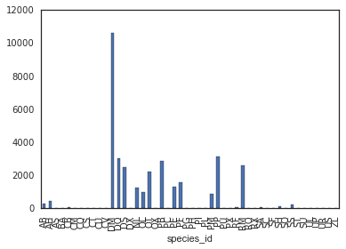

```python
species_counts.plot(kind = 'bar')
```

challenge :: can you get a bar plot for the total number of animals found in each plot?

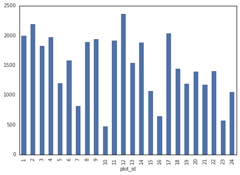

```python
total_count = surveys_df.groupby('plot_id')['record_id'].nunique()
total_count.plot(kind = 'bar')
```

for fancier plots, I like to use a package called seaborn

```python
import seaborn as sns
```

let's do that same plot with seaborn

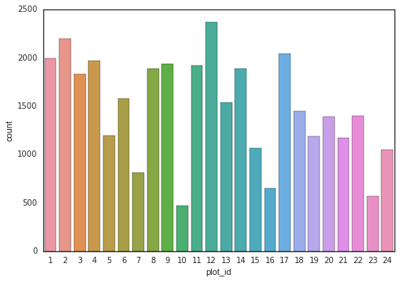

```python
sns.countplot(data = surveys_df, x = 'plot_id')
```

challenge :: try setting the color to blue

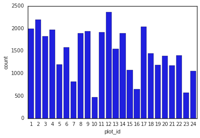

```python
sns.countplot(data = surveys_df, x = 'plot_id', color = 'blue')
```

I tend to prefer it to have a white background and optimized for displaying in this notebook

```python
sns.set_style('white')
sns.set_context('notebook')
```

let's copy-paste that plot back in

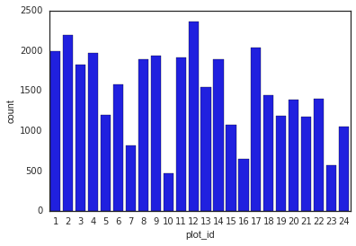

```python
sns.countplot(data = surveys_df, x = 'plot_id', color = 'blue')
```

challenge :: can you differentiate those counts by the sex?

(hint, seaborn uses hue to group categories)

[figure not shown]

```python
sns.countplot(data = surveys_df, x = 'plot_id', hue = 'sex')
```

let's change the color palette

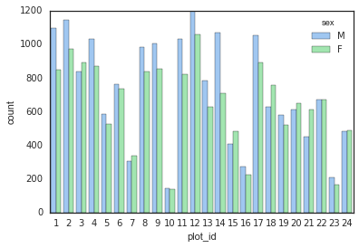

```python
sns.countplot(data = surveys_df, x = 'plot_id', hue = 'sex', palette = 'pastel')
```

seaborn also makes scatter plots easy

it calls them regression plots and gives you a linear regression line

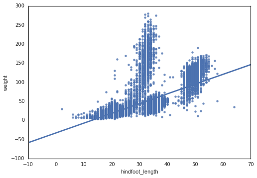

```python
sns.regplot(data = surveys_df, x = 'hindfoot_length', y = 'weight')
```

you can use alpha to see density more clearly

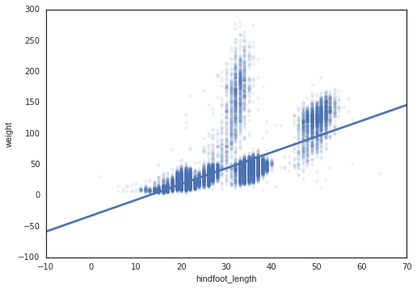

```python
sns.regplot(data = surveys_df, x = 'hindfoot_length', y = 'weight', scatter_kws = {'alpha' : 0.1})
```

to see categories, we can use a different version of a scatter plot, called LM plot

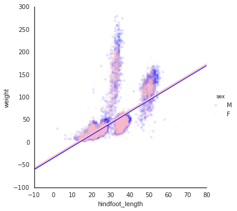

```python
sns.lmplot(data = surveys_df,x = 'hindfoot_length', y = 'weight',
           hue = 'sex', palette = ['blue', 'pink'], scatter_kws = {'alpha' : 0.1})
```